# Analysis - Daims Nitrospira 6 GWW assembly

Mads Albertsen

November 24, 2015

## Introduction

This report documents the binning of a Nitrospira genome from the GWW sample. See [Daims et al., 2015: Complete Nitrification by Nitrospira Bacteria](https://doi.org/10.1038/nature16461) for further details.

## Load the mmgenome package

The metagenome data is analysed using the [mmgenome package](http://madsalbertsen.github.io/mmgenome/).

```r
library("mmgenome")
```

## Import data

The Rmarkdown file [Load_data.Rmd](http://madsalbertsen.github.io/mmgenome/Daims_GWW_Load_data.html) describes the loading of the data and can be imported using the `mmimport` function. However, the preprocessed data can also be downloaded directly from figshare: [Daims_GWW](http://dx.doi.org/10.6084/m9.figshare.1613284). Hence, here we import the prepocessed data from figshare instead.

```r
load("Daims_GWW.RData")
```

## Extract Nitrospira 6

As seen from the overview plots, there are numerous Nitrospira species. This one is located between multiple other species.

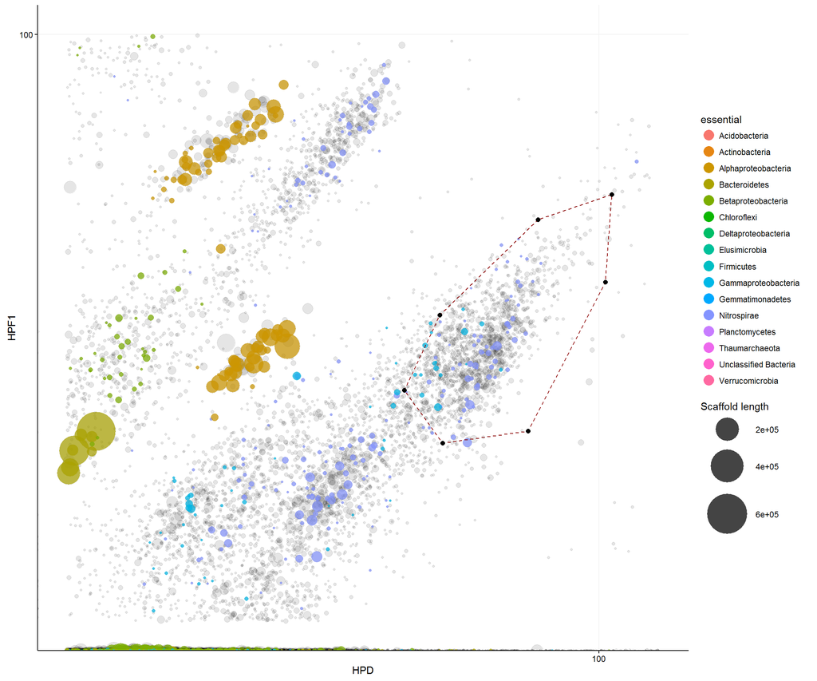

```r
p <- mmplot(data = d,
            x = "HPD",
            y = "HPF1",
            color = "essential",
            minlength = 1000,
            factor.shape = "solid") +
  scale_x_log10(limits=c(20, 120)) +
  scale_y_log10(limits=c(20, 100))

#p
#sel <- mmplot_locator(p)

sel <- data.frame(HPD  =  c(83.2, 61.8, 55.5, 62.3, 80.7, 102, 104),
                  HPF1  =  c(60.2, 46.3, 37.7, 32.6, 33.7, 50.7, 64.5))

mmplot_selection(p, sel)
```

The scaffolds included in the defined subspace are extracted using the `mmextract` function.

```r
dA <- mmextract(d, sel)
```

The `mmstats` function applies to any extracted object. Hence, it can be used directly on the subset.

```r
mmstats(dA, ncov = 2)
```

```
##               General Stats
## n.scaffolds         1326.00
## GC.mean               55.30
## N50                 6226.00
## Length.total     5771838.00
## Length.max         45137.00
## Length.mean         4352.80
## Coverage.HPD          70.44
## Coverage.HPF1         42.39
## Ess.total            157.00
## Ess.unique            91.00
```

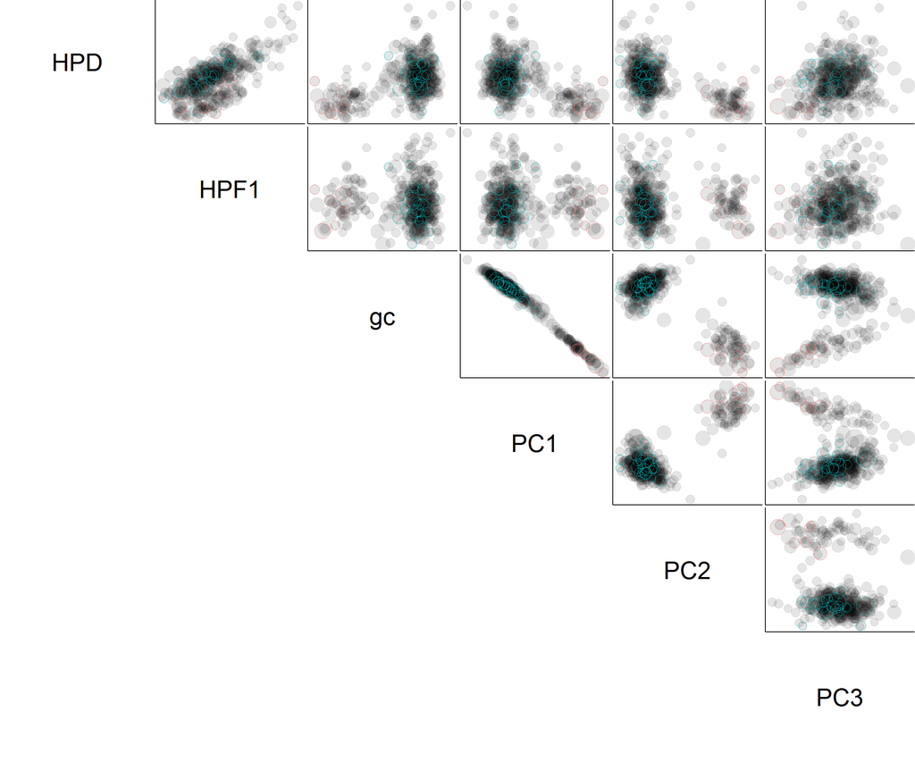

```r
mmplot_pairs(data = dA,
             variables = c("HPD", "HPF1","gc", "PC1", "PC2", "PC3"),
             minlength = 5000,
             color = "essential")
```

## Clean-up other species (Subset B)

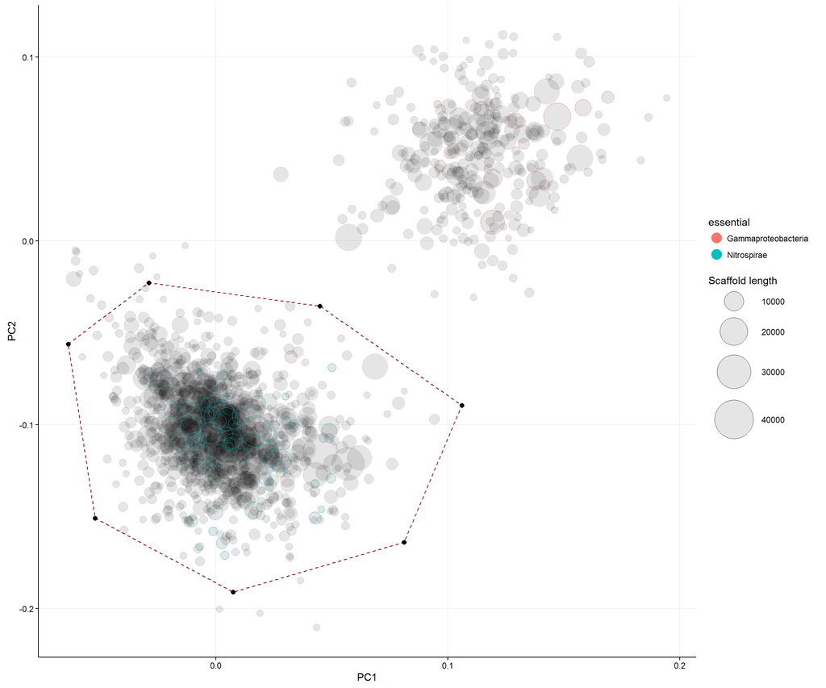

```r
p <- mmplot(data = dA,
            x = "PC1",
            y = "PC2",
            color = "essential",
            minlength = 1000)
#p
#sel <- mmplot_locator(p)

sel <- data.frame(PC1  =  c(-0.0636, -0.0289, 0.0449, 0.106, 0.0812, 0.00744, -0.052),
                  PC2  =  c(-0.0562, -0.0228, -0.0356, -0.0895, -0.164, -0.191, -0.151))

mmplot_selection(p, sel)
```

The scaffolds included in the defined subspace are extracted using the `mmextract` function.

```r
dB <- mmextract(dA, sel)
```

The `mmstats` function applies to any extracted object. Hence, it can be used directly on the subset.

```r
mmstats(dB, ncov = 2)
```

```
##               General Stats
## n.scaffolds         1021.00
## GC.mean               57.70
## N50                 6382.00
## Length.total     4615352.00
## Length.max         45137.00
## Length.mean         4520.40
## Coverage.HPD          72.06
## Coverage.HPF1         42.46
## Ess.total            114.00
## Ess.unique            79.00
```

## Export the scaffolds

Finally the binned scaffolds are exported.

```r
mmexport(data = dB, assembly = assembly, file = "Wolf_Nitrospira6.fa")
```